# Data Analysis for Capital One

## By Maneesh reddy kandula Madhuri talakayala Saketh gandra

The first step is to import all the required packages required for analysis. Below is not the complete list of packages used, A few packages have been installed as required in the code cells below.

```python
import pandas as pd
import matplotlib.pyplot as plt
%matplotlib inline
import seaborn as sns
import numpy as np
import warnings
import csv
import json
warnings.filterwarnings('ignore')
```

## TASK 1: Part A,B

The first task was to design a non-parameterized function called 'hmda_init()' which reads the two datasets from disk and merges them into a single pandas data frame, the function outputs three data frames in total the two original datasets that were loaded from the disk and the merged dataset.

The 'hmda_init()' function calls two more helper functions 'leadingzeros' and 'merge' the first function 'leadinzeros' cleans the two datasets by removing leading zeros in a few columns and the second helper function 'merge' merges the data on the keys 'Respondent_ID','Agency_Code','As_of_Year'. The main function 'hmda_init()' just loads the datasets and calls these two helper functions.

## Note: Give the local file path to the data in the hmda_init() function, in order to run the function successfully.

```python
def hmda_init():
    df= csv.DictReader(open('2012_to_2014_loans_data.csv'), delimiter=',')#give the correct path to read the file succesfully
    dictn = {}
    for row in df:
        for column, value in row.iteritems():
            dictn.setdefault(column, []).append(value)
    loans_data=pd.DataFrame(dictn)
    institutions_data=pd.read_csv('2012_to_2014_institutions_data.csv')
    loans_data,institutions_data=leadingzeros(loans_data,institutions_data)
    return (loans_data,institutions_data,merge(loans_data,institutions_data))
```

```python
def leadingzeros(loans_data,institutions_data):
    institutions_data.loc[:,'Respondent_ID']=institutions_data.loc[:,'Respondent_ID'].str.lstrip('0')
    leadingzerolist=[2,4,9,11,18,19,20,23]
    for i in leadingzerolist:
        loans_data.iloc[:,i]=loans_data.iloc[:,i].str.lstrip('0')
    return (loans_data,institutions_data)
```

```python
def merge(loans_data,institutions_data):
    loans_data.loc[:,['As_of_Year','Agency_Code']]=loans_data.loc[:,['As_of_Year','Agency_Code']].astype('int')
    fulldf=pd.merge(loans_data, institutions_data, on=['Respondent_ID','Agency_Code','As_of_Year'],how='left')
    return (fulldf)
```

Running the hmda_init function and collecting the results into respective dataframes.

```python
loans_data,institutions_data,mergeddf=hmda_init()
```

the 'clean()' function written below handles the blank values by converting them into NaN's and also assigns the appropriate data type to each column of the merged dataframe.

```python
def clean(loans_data,institutions_data,mergeddf):
    intigerlist=loans_data.iloc[:,[2,4,5,9,11,13,16,18,20,22,23]].columns
    intlist=institutions_data.iloc[:,[6,10,11]].columns
    keys=loans_data.iloc[:,[0,3,19]].columns
    categrylist=mergeddf.columns-(intigerlist+intlist+keys)
    mergeddf.loc[:,(intigerlist+intlist)]=mergeddf.loc[:,(intigerlist+intlist)].apply(lambda x:pd.to_numeric(x,errors='coerce'))
    mergeddf=mergeddf.applymap(lambda x: np.nan if x =='' else x)
    mergeddf[categrylist]=mergeddf[categrylist].apply(lambda x:x.astype('category'))
    return (mergeddf)
```

```python
mergeddf=clean(loans_data,institutions_data,mergeddf)
```

## Part C:

The part C of task 1 is to write another function 'hmda_to_json' with two optional parameters and the merged data as another parameter, the function should select data according to the optional parameters and dump the data on to the disk. The 'hmda_to_json' function uses two more helper functions namely 'convert_json' and 'DatetimeEncoder'. the main function selects the data according to the optional parameters chosen by the user and calls the first helper function 'convert_json' which converts the selected data into a type 'dict' and then serializes the data to 'json' eventually. The 'convert_json' function calls another helper function 'DatetimeEncoder' in order to handle serialization of dates. In order to dump the data as per user selection just run the 'hmda_to_json' with the merged data as the first parameter and remaining parameters as necessary.

Note:- The 'DatetimeEncoder' function was taken from stack overflow from the link below http://stackoverflow.com/questions/11875770/how-to-overcome-datetime-datetime-not-json-serializable-in-python

```python
def hmda_to_json(fulldf,state=False,convetionflag=False):
    if state:
        fulldf=fulldf.loc[fulldf['State']==state,]
    if convetionflag:
        fulldf=fulldf.loc[fulldf['Conventional_Conforming_Flag']==convetionflag,]
    convert_json(fulldf)
```

```python
def convert_json(df):
    x=df.to_dict()
    jdict={}
    for k, v in x.iteritems():
        nkey=json.dumps(k)
        jdict[nkey]= x[k].values()
        with open('out.json', 'w+') as f:f.write(json.dumps(jdict,cls=DatetimeEncoder))
```

```python
#http://stackoverflow.com/questions/11875770/how-to-overcome-datetime-datetime-not-json-serializable-in-python
#above link for the code
class DatetimeEncoder(json.JSONEncoder):
    def default(self, obj):
        try:
            return super(DatetimeEncoder, obj).default(obj)
        except TypeError:
            return str(obj)
```

Calling the 'hmda_to_json' function. The function will dump the results as per the selection of parameters in to the current working location

```python
hmda_to_json(mergeddf, state="DC",convetionflag="N")
```

Checking for missing values in all the columns of the merged dataset. The parent attributes of the merged dataset has a lot of missing values, The “Respondent_Name” has no missing values which satisfies one of the requirement for task 1 part A, which is all the institutions should be assigned with a unique “Respondent_Name”. Did not attempt to do any imputation as it was not mentioned as part of any task.

```python
mergeddf.isnull().sum()
#mergeddf.Agency_Code.value_counts()
```

```
Agency_Code                            0
Agency_Code_Description                0
Applicant_Income_000              117856
As_of_Year                             0
Census_Tract_Number                 1677
Conforming_Limit_000                 837
Conforming_Status                      0
Conventional_Conforming_Flag           0
Conventional_Status                    0
County_Code                          837
County_Name                          837
FFIEC_Median_Family_Income          1677
Lien_Status_Description                0
Loan_Amount_000                        0
Loan_Purpose_Description               0
Loan_Type_Description                  0
MSA_MD                             95217
MSA_MD_Description                 95217
Number_of_Owner_Occupied_Units      1874
Respondent_ID                          0
Sequence_Number                        3
State                                  0
State_Code                             0
Tract_to_MSA_MD_Income_Pct          2713
Respondent_Name_TS                     0
Respondent_City_TS                     0
Respondent_State_TS                    0
Respondent_ZIP_Code               197100
Parent_Name_TS                    664653
Parent_City_TS                    664653
Parent_State_TS                   664511
Parent_ZIP_Code                   920810
Assets_000_Panel                       0
dtype: int64
```

## TASK 2: Quality Check.

The tasks in quality check module is to mainly perform quality assessment in the two columns 'Loan_Amount_000'and'Respondent_Name'.

### The Problem:

First assessing the quality in 'Respondent_Name' column, consider the below selection and grouping of various columns as Case A:

Selection Criteria: ‘WELLS FARGO BANK, N.A.'

Grouping on: ['Respondent_ID','Agency_Code','Parent_Name_TS','Respondent_Name_TS']

From the below results of Case A, we can conclude that for each unique combination of 'Respondent_ID' and 'Agency_Code' there is a unique institutional name assigned to it in 'Respondent_Name_TS' ,all these unique institutional names have a common parent name, this is an expected and as per requirements mentioned in part A.

```python
grpdf=mergeddf.loc[mergeddf.Parent_Name_TS=='WELLS FARGO BANK, N.A.',['As_of_Year', 'Respondent_ID','Agency_Code','Respondent_Name_TS','Parent_Name_TS']]
grpdf.groupby(['Respondent_ID','Agency_Code','Parent_Name_TS','Respondent_Name_TS'])['Respondent_Name_TS'].count()
```

```
Respondent_ID  Agency_Code  Parent_Name_TS          Respondent_Name_TS
20-0790865     9            WELLS FARGO BANK, N.A.  NUCOMPASS MORTGAGE SERVICES LL        1
20-4436381     9            WELLS FARGO BANK, N.A.  FIRST COMMONWEALTH HOME MTGE          1
26-3780954     9            WELLS FARGO BANK, N.A.  PREMIA MORTGAGE, LLC                 91
33-0875305     9            WELLS FARGO BANK, N.A.  LINEAR FINANCIAL, LP                 28
41-1914032     9            WELLS FARGO BANK, N.A.  HOMESERVICES LENDING, LLC           117
42-1472314     9            WELLS FARGO BANK, N.A.  EDWARD JONES MORTGAGE, LLC           73
42-1570515     9            WELLS FARGO BANK, N.A.  MILITARY FAMILY HOME LOANS, LL      766
52-1996388     9            WELLS FARGO BANK, N.A.  ADVANCE MORTGAGE                     51
54-1685390     9            WELLS FARGO BANK, N.A.  PROSPERITY MORTGAGE COMPANY       13102
65-1113234     9            WELLS FARGO BANK, N.A.  HOMESALE LENDING, LLC                14
80-0066627     9            WELLS FARGO BANK, N.A.  AIRES MORTGAGE SOLUTIONS, LLC         3
Name: Respondent_Name_TS, dtype: int64
```

Now consider the below grouping of data based on the same columns as Case B:

From the results of Case B, we can see that the ‘Respondent_Name_TS' column has two different names for a unique combination of 'Respondent_ID' and 'Agency_Code'. The results in this case is contridicting the conclusion from Case A that 'Respondent_Name_TS' isunique for each combination of 'Respondent_ID' and 'Agency_Code'. Also we can notice a spelling mistake in the 'Parent_Name_TS' column.

```python
mergeddf.groupby(['Agency_Code','Respondent_ID'])['Parent_Name_TS'].value_counts()
df=mergeddf.loc[mergeddf.Respondent_ID=='12229',['Respondent_Name_TS','Respondent_ID','Agency_Code','As_of_Year','Parent_Name_TS','Sequence_Number']]
df.groupby(['Respondent_ID','Agency_Code','Parent_Name_TS','Respondent_Name_TS'])['Respondent_Name_TS'].count()
```

```
Respondent_ID  Agency_Code  Parent_Name_TS           Respondent_Name_TS
12229          1            NATIOANL BANKSHARES INC  NATIONAL BANK T/A NATIONAL BAN    128
                            NATIONAL BANKSHARES INC  NATIONAL BANK OF BLACKSBURG T/    245
Name: Respondent_Name_TS, dtype: int64
```

### Solution:

The conclusion from both the cases are contradicting each other and this seems like a quality issue with the 'Respondent_Name_TS' column, HMDA should take initiatives to see that the concept of primary keys is strictly enforced on the tables and the above observations from both the cases seems like an issue with database update. HMDA should make sure that every time they update the database with an already existing combination of 'Respondent_ID' and 'Agency_Code' names there should be a validator in place to check if the names match with the existing names in the table or not before updating the table, and if the responding institute is updating its name there should be another validator that should check if the existing records are also updated accordingly or not with the new name for completeness, this ensures data integrity and quality. By implementing these kind of database updating validators for other columns like Parent_Name_TS such issues can be eradicated.

### Problem:

Now consider the other column of intrest: 'Loan_Amount_000':

One issue with this column is there are a lot of outliers, all the types of loans tagged as jumbo have a very high mean value than the conforming loans we can see tha from the below tabulated results for each loan type this can cause issues in prediction if not normalized, but the major issue with this column is there are missing entries for a loan category, consider the NaN's in the Jumbo loan type of the below table for the 'FSA/RHS guaranteed' loan category for the states 'DE' and 'WV', and also the loan category is completly missing for all the years in the state of 'DC'.

```python
mergeddf.groupby(['As_of_Year' ,'State','Loan_Type_Description','Conforming_Status'])['Loan_Amount_000'].mean().unstack()
```

| As_of_Year | State | Conforming_Status Loan_Type_Description | Conforming | Jumbo |
| --- | --- | --- | --- | --- |
| 2012 | DC | Conventional | 338.255295 | 916.214320 |
|  |  | FHA insured | 316.497722 | 710.287293 |
|  |  | VA guaranteed | 391.382155 | 745.808081 |
|  | DE | Conventional | 197.593050 | 673.258794 |
|  |  | FHA insured | 196.325451 | 375.090909 |
|  |  | FSA/RHS guaranteed | 184.816032 | NaN |
|  |  | VA guaranteed | 234.225045 | 463.342105 |
|  | MD | Conventional | 254.799463 | 773.028727 |
|  |  | FHA insured | 242.797275 | 579.258211 |
|  |  | FSA/RHS guaranteed | 207.881691 | 240.600000 |
|  |  | VA guaranteed | 305.811407 | 617.214286 |
|  | VA | Conventional | 251.735915 | 1869.336952 |
|  |  | FHA insured | 228.409441 | 648.090656 |
|  |  | FSA/RHS guaranteed | 155.751020 | 418.666667 |
|  |  | VA guaranteed | 296.438952 | 679.286093 |
|  | WV | Conventional | 135.674081 | 6089.257485 |
|  |  | FHA insured | 136.375442 | 104.500000 |
|  |  | FSA/RHS guaranteed | 131.904972 | NaN |
|  |  | VA guaranteed | 182.494175 | 532.545455 |
| 2013 | DC | Conventional | 327.381971 | 919.187671 |
|  |  | FHA insured | 304.338521 | 716.720000 |
|  |  | VA guaranteed | 388.890661 | 770.802721 |
|  | DE | Conventional | 193.186100 | 685.651297 |
|  |  | FHA insured | 191.813483 | 360.862069 |
|  |  | FSA/RHS guaranteed | 191.706112 | 315.000000 |
|  |  | VA guaranteed | 232.083199 | 489.966667 |
|  | MD | Conventional | 243.068622 | 779.255470 |
|  |  | FHA insured | 236.077281 | 586.109635 |
|  |  | FSA/RHS guaranteed | 209.800000 | 620.200000 |
|  |  | VA guaranteed | 302.872790 | 622.882605 |
|  | VA | Conventional | 241.397329 | 1749.681124 |
|  |  | FHA insured | 219.598073 | 668.602083 |
|  |  | FSA/RHS guaranteed | 163.802044 | 209.000000 |
|  |  | VA guaranteed | 289.822757 | 701.793827 |
|  | WV | Conventional | 134.456619 | 4099.125523 |
|  |  | FHA insured | 135.062118 | NaN |
|  |  | FSA/RHS guaranteed | 135.270197 | 61.000000 |
|  |  | VA guaranteed | 184.586141 | 503.636364 |
| 2014 | DC | Conventional | 344.187624 | 918.244287 |
|  |  | FHA insured | 315.415118 | 704.487179 |
|  |  | VA guaranteed | 410.266319 | 772.729412 |
|  | DE | Conventional | 203.123380 | 606.432836 |
|  |  | FHA insured | 186.416293 | 140.000000 |
|  |  | FSA/RHS guaranteed | 189.097451 | NaN |
|  |  | VA guaranteed | 235.241082 | 531.695652 |
|  | MD | Conventional | 255.331612 | 772.152767 |
|  |  | FHA insured | 233.527745 | 544.995025 |
|  |  | FSA/RHS guaranteed | 203.995552 | 444.000000 |
|  |  | VA guaranteed | 308.736711 | 619.470175 |
|  | VA | Conventional | 250.402238 | 1962.103847 |
|  |  | FHA insured | 215.800114 | 606.105263 |
|  |  | FSA/RHS guaranteed | 163.282037 | 341.250000 |
|  |  | VA guaranteed | 290.259646 | 688.543498 |
|  | WV | Conventional | 134.471962 | 5096.822472 |
|  |  | FHA insured | 127.203540 | 87.333333 |
|  |  | FSA/RHS guaranteed | 131.124389 | NaN |
|  |  | VA guaranteed | 177.657702 | 450.000000 |

### Solution:

HMDA needs to ensure that loan amount is recorded for each loan category of data every year. and this can be done by again running a validator similar to the one specified in the above solution, but it is more logical to have a validator run once in every few months to check if the ongoing year has records for all kinds of loan types.

# Task 3: Visualization

The question of interest here for change financials is, whether or not it is a good idea to enter the home loans market. To answer the question let us take help of visualization, which is a very effective way of finding and conveying insights.

First visualizing the distribution of Loan_Amount_000, the density plot shows that the distribution is heavily right skewed and a lot of values fall in the lower bin indicating a lot of loans are under the conforming limit and the observations on the right tale indicate jumbo status loans.

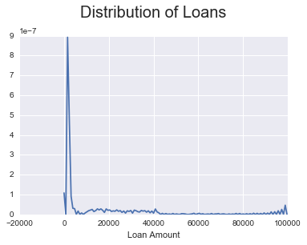

```python
sns.distplot(mergeddf.Loan_Amount_000,hist=False)
plt.title("Distribution of Loans",y=1.08,size=20)
plt.xlabel('Loan Amount')
```

The density plot of Applicant income is also similar to the density plot of loans this is as expected because applicants with low income generally apply for loan amounts which are less or close to the confirming limit.

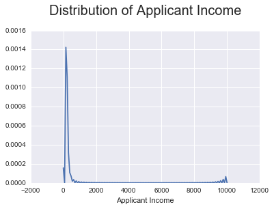

```python
sns.distplot(mergeddf.Applicant_Income_000,hist=False)
plt.title("Distribution of Applicant Income",y=1.08,size=20)
plt.xlabel('Applicant Income')
```

To get a better understanding of how these two columns loan and applicant income and how they interplay, consider the below plot which visualizes the loans and applicant income averages together in the same plot. In the below plot the blue color lines plot on the top is the average of loans applied through the years, one can notice that in year 2014 the average loans increased, and the green color lines plot is the applicant average income, and as we can see the loans applied are close to twice the average of applicants incomes.

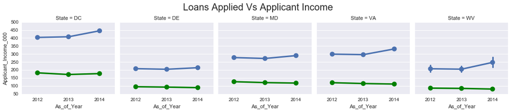

```python
ax=sns.FacetGrid(mergeddf,col='State',col_wrap=5)
ax.map(sns.pointplot,'As_of_Year','Loan_Amount_000',labels='Loan Amount' )
ax.map(sns.pointplot,'As_of_Year','Applicant_Income_000',color='g',labels='Income Amount')
# handles, labels = ax.
ax.add_legend()
plt.suptitle('Loans Applied Vs Applicant Income',y=1.08,size=20)
# plt.legend([Loans Applied, Applicant Income],[])
```

#### Note : 'Blue' : average loans amount , 'Green' : average applicant income.

Let us now plot a pair plot to check and compare if there is any pairwise linear relationship amongst the various integer variables of interest present in the data, namely 'Loan_Amount_000', 'FFIEC_Median_Family_Income', 'Conforming_Limit_000', 'Assets_000_Panel' and 'Applicant_Income_000'. The plots throughout the diagonal are just histogram distribution of the variables of interest

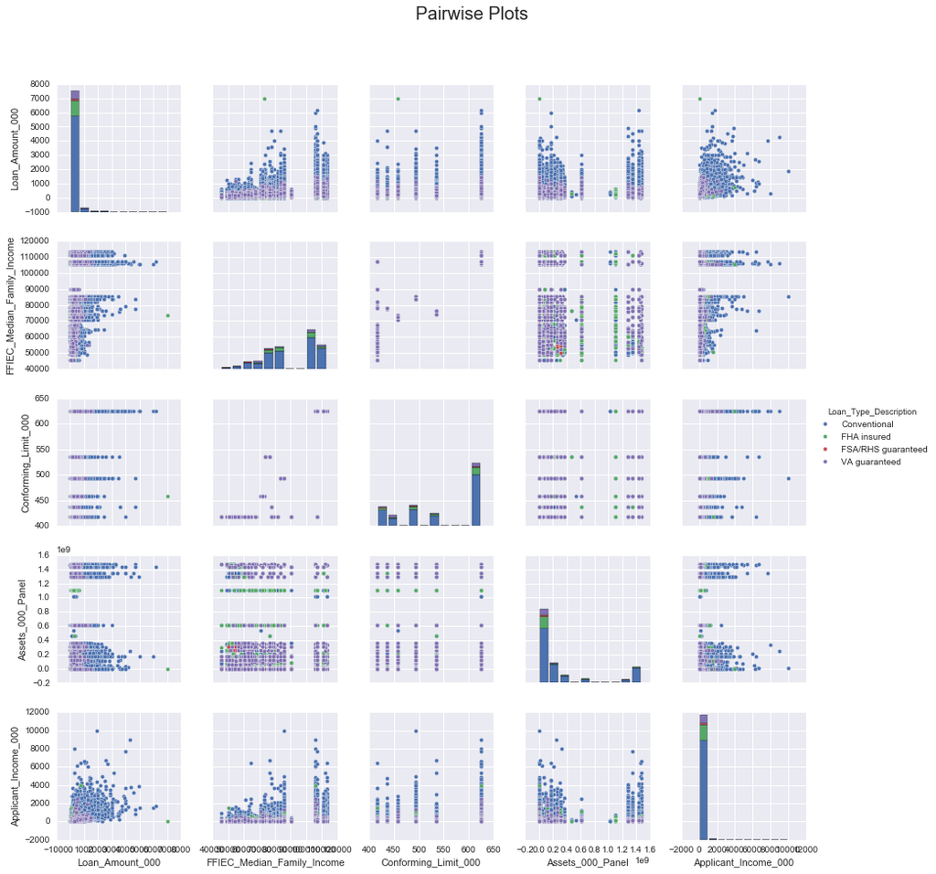

```python
sns.pairplot(data=mergeddf.dropna(),vars=['Loan_Amount_000','FFIEC_Median_Family_Income','Conforming_Limit_000','Assets_000_Panel',
                                 'Applicant_Income_000'],dropna=True,hue='Loan_Type_Description')
plt.suptitle("Pairwise Plots",y=1.08,size=20)
```

There is no significant linear relationships amongst the variables of interest as we can see from the above plot, but there are random Patterns in a few plots that can be noticed above, this implies additional exploration is required to derive meaningful relations.

Let us now try to see the distribution of loans by loan types for each state, and for doing such kind of visulizations, factor plot is a good option.

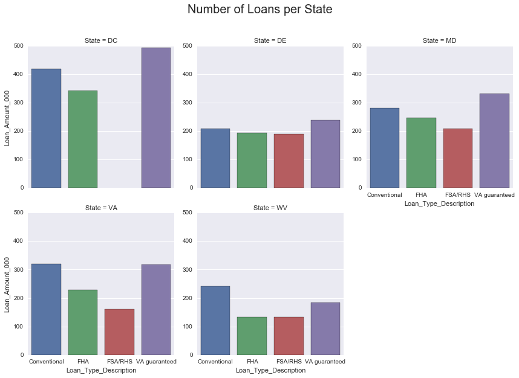

```python
ax=sns.factorplot(x="Loan_Type_Description", y="Loan_Amount_000", col="State",data=mergeddf,kind="bar",legend_out=True,
                  ci=None,sharey=False,col_wrap=3)
ax.set_xticklabels(["Conventional","FHA","FSA/RHS","VA guaranteed"])
ax.set(ylim=(0, 500))
plt.suptitle('Number of Loans per State',y=1.08,size=20)
```

Plotting influence on market share of the applied loans by factors like state and year.

From the first plot below which visualizes market share by year, we can see that the market share for loans is decreasing year by year at a rate close to 10%, but we cannot conclude by this that the market is degrading in performance year after year as the data at hand is the loans application data, and we have no data about how many of these applied loans were sanctioned and how many were rejected. Which makes it difficult to make an inference right away.

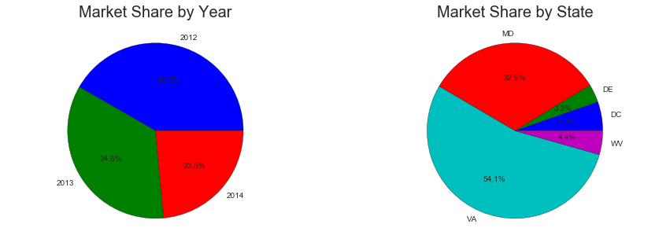

```python
from matplotlib.pyplot import pie, axis, show
plt.figure(figsize=(15,5))


ax1  = plt.subplot(1,2,1)
agg = mergeddf.Loan_Amount_000.groupby(mergeddf.As_of_Year).sum()
axis('equal');
plt.pie(agg, labels=agg.index,autopct="%1.1f%%");
plt.title("Market Share by Year", fontsize = 20)


ax2  = plt.subplot(1,2,2)
agg = mergeddf.Loan_Amount_000.groupby(mergeddf.State).sum()
axis('equal');
plt.pie(agg, labels=agg.index,autopct="%1.1f%%");
plt.title("Market Share by State", fontsize = 20)
plt.show()
```

The below two pie charts are visualization of market share by Loan type and loan status, as we can see 70% of market share is in conventional loan types.

In the second pie chart the conforming status loans take the major share of 80% and jumbo loans constitute to 20% which is visibly large even though the total number of jumbo loans are not more than 5% of all the loans, this implies jumbo loans are crucial for business because of their magnitude. So more exploration needs to be done on the jumbo loan staus.

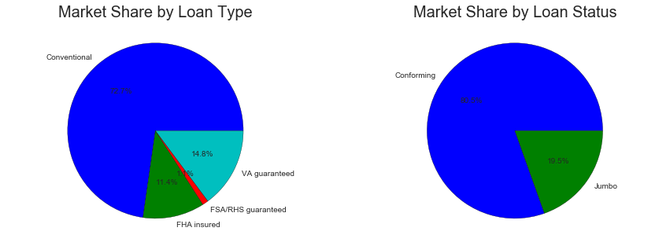

```python
plt.figure(figsize=(15,5))
ax1  = plt.subplot(1,2,1)
agg = mergeddf.Loan_Amount_000.groupby(mergeddf.Loan_Type_Description).sum()
axis('equal');
plt.pie(agg, labels=agg.index,autopct="%1.1f%%");
plt.title("Market Share by Loan Type", fontsize = 20)


ax2  = plt.subplot(1,2,2)
agg = mergeddf.Loan_Amount_000.groupby(mergeddf.Conforming_Status).sum()
axis('equal');
plt.pie(agg, labels=agg.index,autopct="%1.1f%%");
plt.title("Market Share by Loan Status", fontsize = 20)
plt.show()
```

```python
mergeddf['Percent_Change']=(mergeddf.Loan_Amount_000-mergeddf.Conforming_Limit_000)/mergeddf.Conforming_Limit_000*100
#mergeddf.columns
```

In the below plot we are trying to visualize how huge are the jumbo loans using the column created above. In the below plot we can consider the x axis to be the conforming limit, and the below plots visualize the average of each loan types through the years. The plot on the left describes what percentage less are the confriming loans than the limit year over year and it seems to be constant showing market stability. The second plot on the right visualizes how big the jumbo loans are in terms of percentage than the conforming limit. As we can see the jumbo loans for conventional type of loans starts at 150% higher than the conforming limit and the trend seems to be only increasing after a slight drop in 2013.

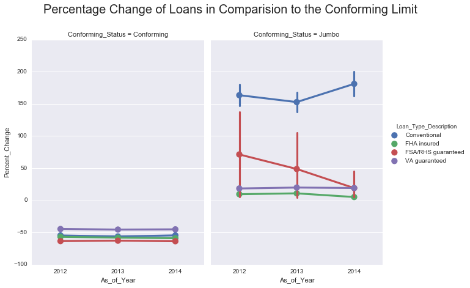

```python
ax=sns.factorplot(x='As_of_Year',y='Percent_Change',hue='Loan_Type_Description', col="Conforming_Status", data=mergeddf,
                   capsize=.2, size=6, aspect=.75)
plt.suptitle('Percentage Change of Loans in Comparision to the Conforming Limit',y=1.08, fontsize = 20)
```

#### Note: X axis at zero is the conforming limit.

# TASK 4: